# Comparativa estrategia Pasiva vs Activa

Tarea 3

Published

February 16, 2025

```python
import pandas as pd
import numpy as np
import warnings

import matplotlib.pyplot as plt
import seaborn as sns

sns.set_style("darkgrid")

from portfolio_utils import AssetsResearch
import yfinance as yf

try:
    from pandas.errors import Pandas4Warning
    warnings.filterwarnings("ignore", category=Pandas4Warning, module="yfinance")
except Exception:
    pass
```

# 1 Estrategia Activa

## 1.1 Resumen ejecutivo

Tu estrategia de inversión activa contiene las siguientes acciones con ponderaciones equitativas:

| Empresa | Ticker |
| --- | --- |
| JPMorgan Chase & Co. | JPM |
| Visa Inc. | V |
| The Goldman Sachs Group, Inc. | GS |
| The Progressive Corporation | PGR |

Todos aunque se encuentren dentro de un mismo sector, dada la composición de sus ingresos se puede presumir que tiene modelos de negocios diferentes y por tanto, métricas de valuación distintas.

Es decir, dado que cada compañía genera ingresos de diferentes maneras, cada una de estas posee diferentes mercado objetivo, productos específicos y procesos de generación de efectivo. Por tanto, lo ideal sería realizar una valuación en función de las particularidades de cada compañía y de esta forma obtener un precio objetivo con la intención de evaluar la rentabilidad de esta inversión.

En primer lugar, tenemos a **JP Morgan (JPM)** quien cuenta con dos grandes líneas de negocio, Banking e Investment Services, diversificados en la mismo nivel.

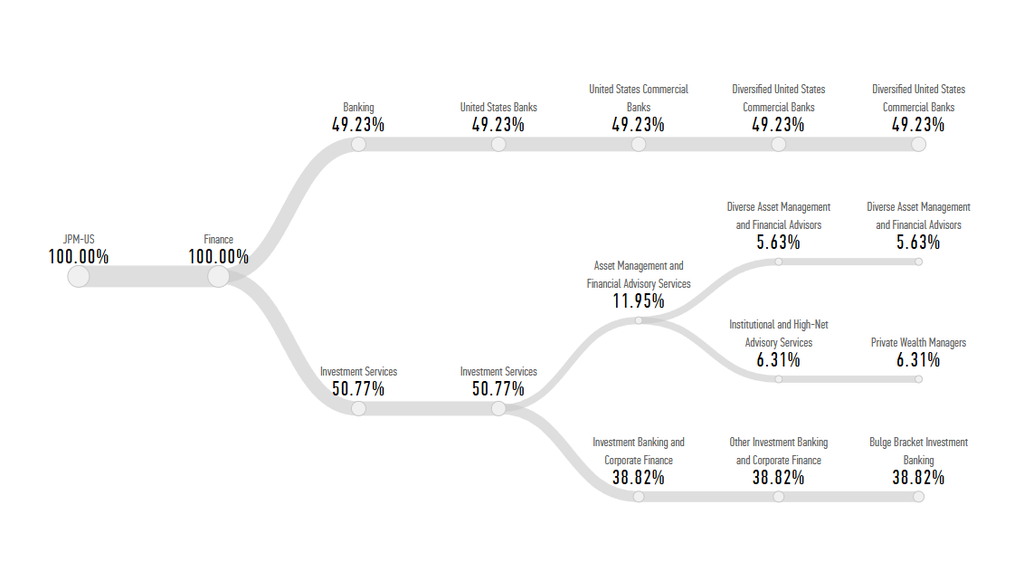

JPM Revenue Exposure by Sector / Industry

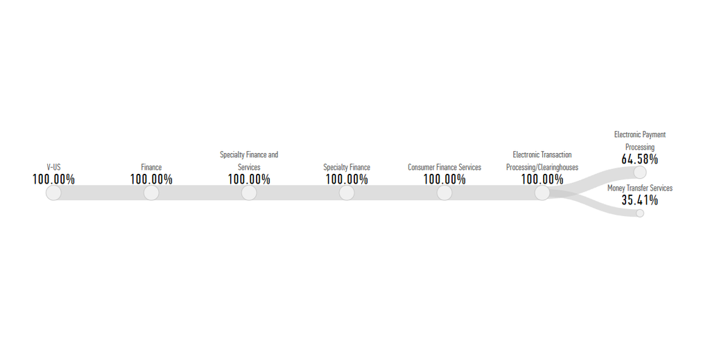

V Revenue Exposure by Sector / Industry

Por otro lado, esta **Goldman Sachs (GS)**, quien es prácticamente un banco de inversión dado que el 95.99% de sus ingresos de su último reporte corresponde con este clase de servicio, claro que después de este nodo se desprenden una gran cantidad de líneas de negocio, sin embargo, el grueso de sus ingresos se encuentran clasificados en esta categoría.

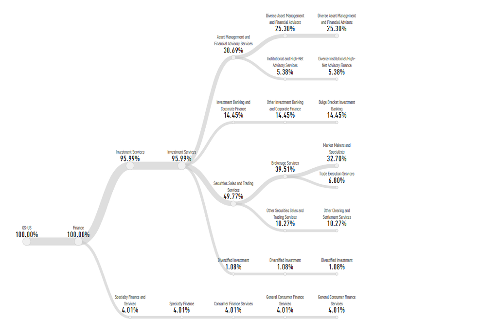

GS Revenue Exposure by Sector / Industry

Por último, en la composición de este portafolio se encuentra **Progressive Corporation (PGR)**, la cual es una compañía dedicada exclusivamente a la venta de seguros.

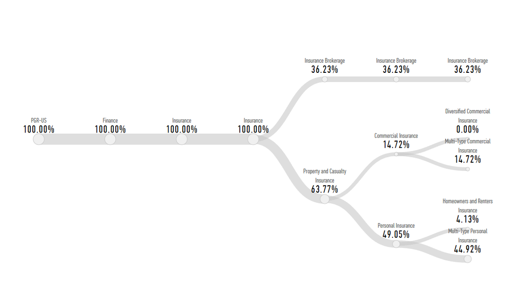

PGR Revenue Exposure by Sector / Industry

Sin embargo, existen métricas “universales” que nos podrían ayudar a comparar la rentabilidad de las diferentes inversiones.

| Empresa | EPS | PE | Dividend Yield (%) |
| --- | --- | --- | --- |
| JPM-US | 20.02 | 15.11 | 1.98 |
| V-US | 10.55 | 29.76 | 0.85 |
| GS-US | 51.32 | 17.64 | 1.99 |
| PGR-US | 19.23 | 11.84 | 6.80 |

- **EPS (Earnings Per Share):** utilidad neta atribuible a accionistas comunes / acciones promedio ponderadas.
- **PE (Price to Earnings):** precio por acción / EPS.
- **Dividend Yield:** tasa de ingreso efectivo que paga una acción en relación con su precio actual.

Dos de estos activos pueden ser clasificados como defensivos y en este sentido hacen mucho sentido sus cifras, dado que tanto para JPM y PGR los múltiplos a los que se pagan son relativamente conservadores, así como un rendimiento promedio en el mercado.

Por otro lado está Visa, quien se paga a un múltiplo significativamente mayor (PE cercano a 30) porque el mercado la percibe como un negocio de alta calidad y crecimiento estructural: una red de pagos con alta escalabilidad, márgenes elevados y baja intensidad de capital. Esa “prima” suele venir acompañada de un **Dividend Yield** menor, ya que gran parte del retorno esperado se explica más por apreciación del precio (y, en muchos casos, recompras) que por pago de dividendos.

Finalmente, GS presenta un PE intermedio pese a tener un EPS elevado, lo cual puede interpretarse como una señal de que el mercado descuenta mayor ciclicidad y variabilidad de utilidades (por su exposición a mercados y banca de inversión). Su rendimiento por dividendo es similar al de JPM, sugiriendo un perfil más balanceado entre ingreso y crecimiento.

En conjunto, el portafolio combina componentes más defensivos (JPM, PGR), una apuesta de crecimiento de alta calidad (V) y una exposición más cíclica (GS), lo que ayuda a diversificar las fuentes de retorno dentro del sector financiero.

| Concepto | JPM | V | GS | PGR |
| --- | --- | --- | --- | --- |
| Stock price | 302.55 | 314.08 | 905.14 | 204.53 |
| Assets | 4,424,900 | 96,814 | 1,810,000 | 123,039 |
| Liabilities | 4,062,462 | 58,037 | 1,685,000 | 92,716 |
| Equity | 362,438 | 38,777 | 125,000 | 30,323 |
| Share out | 2,722 | 1,906 | 299 | 586 |
| Tobin’s q (Ratio) | 1.10 | 6.78 | 1.08 | 1.73 |

*all figures in millions of U.S. Dollar*

- **Tobin’s q:** compara la valoración de mercado de la empresa contra el valor de sus activos. En términos prácticos, un `q` mayor a 1 sugiere que el mercado está dispuesto a pagar una prima sobre la base de activos (por expectativas de crecimiento, rentabilidad, intangibles o poder de mercado); un `q` cercano a 1 indica una valoración más “anclada” al balance; y un `q` menor a 1 sugeriría descuento relativo.

En este set, **JPM (1.10)** y **GS (1.08)** presentan un `q` muy cercano a 1. Esto es consistente con modelos de negocio intensivos en balance, donde buena parte del valor se explica por activos y pasivos financieros (y donde el mercado suele castigar o premiar más por ciclo, riesgo y calidad del balance que por “intangibles” puros). En ambos casos, el tamaño de activos y pasivos es enorme en relación con el equity, lo que también refleja el apalancamiento inherente a la banca, haciendo que pequeñas variaciones en valuación o en expectativas de rentabilidad puedan mover significativamente la percepción de riesgo.

Por otro lado, **PGR (1.73)** ya muestra una prima más marcada. En aseguradoras, esa prima suele estar ligada a disciplina de suscripción, eficiencia operativa y capacidad de crecer utilidades sin expandir proporcionalmente el balance. Aquí, aunque su equity (30,323) es menor, el mercado aparenta asignar valor adicional por la calidad del negocio y su generación de retornos, lo que se refleja en un `q` por encima de 1.

Finalmente, **V (6.78)** es el outlier: un `q` extremadamente alto. Esto suele ocurrir en empresas donde el valor está mucho más en los **intangibles y en la escalabilidad del modelo** que en la magnitud de activos físicos o financieros. Visa opera una red de pagos con efectos de red, márgenes elevados y baja intensidad de capital relativa; por eso su valuación se despega del balance y el mercado paga una prima grande frente a sus activos contables. En otras palabras, el “activo” más valioso no se ve completo en el rubro de Assets del balance.

Es por lo anterior que podemos decir que, el ratio `q` ayuda a distinguir dos perfiles dentro del mismo universo financiero (portfolio): entidades más “balance-driven” (JPM, GS) con valoración cercana al valor de activos, una aseguradora con prima moderada (PGR) y una plataforma/red con fuerte componente intangible (V) cuyo valor de mercado está dominado por expectativas de crecimiento y ventajas competitivas.

Para finalizar, el análisis de los precios de los activos.

| Empresa | Market Price (USD) | Book Price (USD) | P/B | Objective Price (USD) | O/P | 1Y return (%) |
| --- | --- | --- | --- | --- | --- | --- |
| JPM-US | 302.55 | 133.14 | 2.27 | 350.92 | 1.16 | 9.52 |
| V-US | 314.08 | 20.34 | 15.44 | 405.15 | 1.29 | -11.23 |
| GS-US | 905.14 | 418.06 | 2.17 | 960.62 | 1.06 | 37.03 |
| PGR-US | 204.53 | 51.71 | 3.96 | 245.30 | 1.20 | -22.11 |

Visto como portafolio, estos cuatro activos combinan dos perfiles “balance-driven” (JPM y GS), una aseguradora con prima moderada (PGR) y un negocio claramente “asset-light” con fuerte componente intangible (V). Esa mezcla explica por qué los múltiplos y los retornos recientes se comportan de forma tan dispar.

En primer lugar, el **P/B** refleja cómo el mercado valora a cada compañía respecto a su capital contable. **JPM (2.27)** y **GS (2.17)** cotizan a múltiplos relativamente cercanos entre sí, consistentes con instituciones donde el balance y la rentabilidad ajustada a riesgo dominan la valoración. **PGR (3.96)** muestra una prima mayor, común cuando el mercado reconoce disciplina de suscripción, eficiencia y calidad en la generación de utilidades. En contraste, **V (15.44)** es el outlier: un P/B tan elevado suele indicar que gran parte del valor proviene de intangibles, escalabilidad y poder de red más que de activos contables.

En segundo lugar, el **O/P** sugiere que, según el objetivo de precio usado, hay margen de apreciación en todo el portafolio (todos > 1). El mayor “upside” está en **V (1.29)** y **PGR (1.20)**, mientras que **JPM (1.16)** es moderado y **GS (1.06)** es el más acotado, lo que puede interpretarse como que GS ya capturó parte importante de su recuperación.

Finalmente, el **retorno a 1 año** confirma esa lectura: **GS (+37.03%)** y **JPM (+9.52%)** han tenido mejor desempeño, mientras **V (-11.23%)** y **PGR (-22.11%)** han sufrido correcciones. Esto sugiere que el portafolio no está moviéndose por un solo driver: una parte está siendo favorecida por ciclo/valoración del sector financiero (GS/JPM), mientras otra parte refleja ajuste de expectativas o compresión de múltiplos (V/PGR).

En conjunto, podemos concluir que el portafolio se encuentra razonablemente diversificado dentro del sector.

## 1.2 Métricas de riesgo y rendimiento del portafolio

Definimos el conjunto de tickets del portafolio y los pesos

```python
tickers = ["JPM", "V", "GS", "PGR"]
w =  np.ones(len(tickers)) / len(tickers)
```

Descargamos la información correspondiente al precio de los activos.

```python
start_date = "2018-01-01"
end_date = "2026-02-13"

portfolio_prices = yf.download(
    tickers=tickers,
    start=start_date,
    end=end_date,
    auto_adjust=True,
    progress=False,
)["Close"]

portfolio_prices.head(3)
```

| Ticker Date | GS | JPM | PGR | V |
| --- | --- | --- | --- | --- |
| 2018-01-02 | 214.265976 | 86.340889 | 42.759357 | 108.111900 |
| 2018-01-03 | 212.271423 | 86.428871 | 42.736176 | 109.188217 |
| 2018-01-04 | 215.238113 | 87.667015 | 42.728462 | 109.594200 |

### 1.2.1 Rendimiento

```python
def geometric_mean(returns : pd.DataFrame | pd.Series) -> pd.Series | float:
    result1 = (1 + returns)
    result2 = result1.prod()
    result3 = result2 ** (1 / len(returns))
    return result3 - 1


def harmonic_measure(returns: pd.DataFrame | pd.Series) -> pd.Series | float:
    result1 = (1 + returns)
    result2 = 1 / result1
    result3 = result2.sum()
    result4 = len(returns) / result3
    return result4 - 1
```

```python
portfolio_returns = portfolio_prices.pct_change().dropna()
portfolio_returns.head(3)
```

| Ticker Date | GS | JPM | PGR | V |
| --- | --- | --- | --- | --- |
| 2018-01-03 | -0.009309 | 0.001019 | -0.000542 | 0.009956 |
| 2018-01-04 | 0.013976 | 0.014326 | -0.000180 | 0.003718 |
| 2018-01-05 | -0.005101 | -0.006420 | 0.003796 | 0.023949 |

Métricas individuales de rendimiento de los activos

```python
assets_annual_returns = portfolio_returns.mean() * 252
assets_annual_returns
```

```
Ticker
GS     0.226125
JPM    0.197109
PGR    0.228048
V      0.169165
dtype: float64
```

Métrica del rendimiento del portafolio

```python
portfolio_annual_return = np.sum(w * assets_annual_returns)
portfolio_annual_return
```

```
np.float64(0.20511170834224607)
```

medida **geometrica** del rendimiento.

Por activo

```python
assets_anunual_geometric_return = geometric_mean(portfolio_returns) * 252
assets_anunual_geometric_return
```

```
Ticker
GS     0.178060
JPM    0.155059
PGR    0.194063
V      0.135755
dtype: float64
```

del portafolio

```python
portfolio_total_returns = np.sum(w * portfolio_returns, axis=1)
portfolio_anunual_geometric_return = geometric_mean(portfolio_total_returns) * 252
portfolio_anunual_geometric_return
```

```
np.float64(0.17942351833635062)
```

medida **armonica** del rendimiento

por activo

```python
assets_anunual_harmonic_return = harmonic_measure(portfolio_returns) * 252
assets_anunual_harmonic_return
```

```
Ticker
GS     0.129966
JPM    0.112972
PGR    0.159912
V      0.102309
dtype: float64
```

```python
portfolio_anunual_harmonic_return = harmonic_measure(portfolio_total_returns) * 252
portfolio_anunual_harmonic_return
```

```
np.float64(0.15367783189618311)
```

### 1.2.2 Riesgo

Riesgo individual de los activos

```python
assets_annual_vol = portfolio_returns.std() * np.sqrt(252)
assets_annual_vol
```

```
Ticker
GS     0.310464
JPM    0.290378
PGR    0.260404
V      0.258679
dtype: float64
```

Riesgo del portafolio

```python
cov = portfolio_returns.cov()

portfolio_annual_vol = np.sqrt((w.T @ cov @ w)) * np.sqrt(252)
portfolio_annual_vol
```

```
np.float64(0.22671753840157824)
```

### 1.2.3 Métricas de rendimiento ajustadas al riesgo

Coeficiente de variación de los activos individual

```python
cv = assets_annual_vol / assets_annual_returns
cv
```

```
Ticker
GS     1.372977
JPM    1.473187
PGR    1.141881
V      1.529154
dtype: float64
```

Coeficiente de variación del portafolio

```python
portfolio_cv = portfolio_annual_vol/portfolio_annual_return
portfolio_cv
```

```
np.float64(1.1053368929251033)
```

Ratio de Sharpe

```python
# Tasa libre de riesgo 1M
free_risk_rate = 0.03

sharpe_ratio = (portfolio_annual_return - free_risk_rate) / portfolio_annual_vol

sharpe_ratio
```

```
np.float64(0.7723783064020207)
```

### 1.2.4 Matriz de correlación

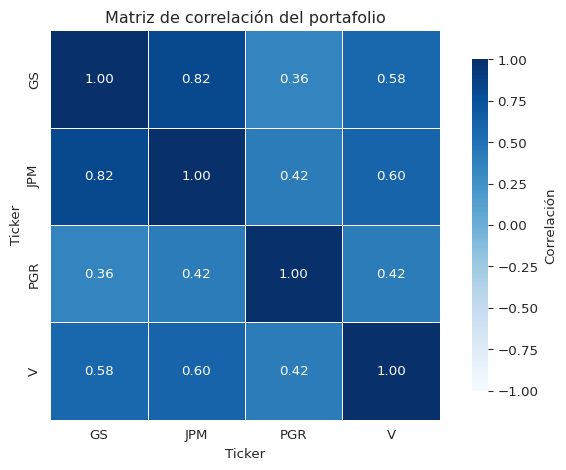

```python
corr = portfolio_returns.corr()

sns.heatmap(
    corr,
    cmap=sns.color_palette("Blues", as_cmap=True),
    vmin=-1, vmax=1, center=0,
    annot=True, fmt=".2f",
    linewidths=0.6, linecolor="white",
    square=True,
    cbar_kws={"label": "Correlación", "shrink": 0.85},
)

plt.title("Matriz de correlación del portafolio")
plt.tight_layout()
plt.show()
```

Mientras más grande la correlación peor serán los efectos de la materialización de riesgo del sector para el portafolio.

# 2 Estrategia Pasiva

Ahora bien, como ya lo hemos mencionado, todas y cada una de estas compañías se dedica a través de diferentes modelos de negocio a la finanzas.

Por tanto, tras una investigación decidí utilizar el **Russell 1000 Financials 40 Act 15/22.5 Daily Capped Index** el cual es un índice sectorial de acciones financieras de EEUU que es donde se encuentra nuestro portafolio. Su rasgo distintivo es que incorpora un mecanismo de capping trimestral y monitoreo diario (“daily capped”) diseñado para limitar la concentración de emisoras y mantener pesos por debajo de umbrales regulatorios asociados al Investment Company Act of 1940.

En este sentido, el ETF que se utilizará a manera de comparativa del rendimiento del portafolio es el iShares U.S. Financials (IYF) (NYSE Arca) que busca replicar este índice.

A continuación se muestra una comparativa respecto de los pesos asignados por el indice y por el portafolio.

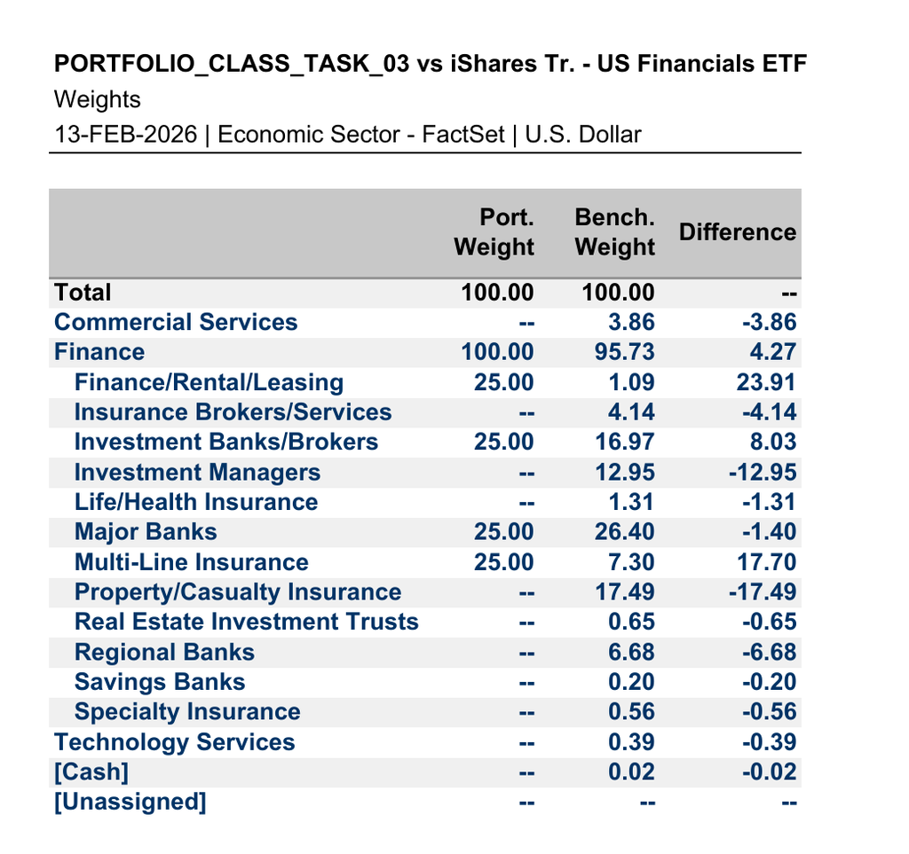

Benchmark weights

```python
benchmark = "IYF"

benchmark_prices = yf.download(
    tickers=benchmark,
    start=start_date,
    end=end_date,
    auto_adjust=True,
    progress=False,
)["Close"]

benchmark_prices.head(3)
```

| Ticker Date | IYF |
| --- | --- |
| 2018-01-02 | 52.066956 |
| 2018-01-03 | 52.241714 |
| 2018-01-04 | 52.495117 |

```python
bechmark_returns = benchmark_prices.pct_change().dropna()
bechmark_returns.head(3)
```

| Ticker Date | IYF |
| --- | --- |
| 2018-01-03 | 0.003356 |
| 2018-01-04 | 0.004851 |
| 2018-01-05 | 0.003995 |

## 2.1 Métricas de riesgo y rendimiento del Benchmark

### 2.1.1 Riesgo

```python
benchmark_annual_vol = bechmark_returns.std() * np.sqrt(252)
benchmark_annual_vol
```

```
Ticker
IYF    0.223982
dtype: float64
```

### 2.1.2 Rendimiento

```python
bechmark_returns = benchmark_prices.pct_change().dropna()

benchmark_annual_return = bechmark_returns.mean() * 252
benchmark_annual_return
```

```
Ticker
IYF    0.131772
dtype: float64
```

### 2.1.3 Metricas de rendimiento ajustadas al riesgo

```python
benchmark_sharpe_ratio = (benchmark_annual_return - free_risk_rate)/benchmark_annual_vol

benchmark_sharpe_ratio
```

```
Ticker
IYF    0.454375
dtype: float64
```

# 3 Conclusiones

Con base en las métricas obtenidas, personalmente invertiría en la estrategia activa, dada su relación riesgo rendimiento respecto de la estrategia pasiva. Aunque actualmente este cuenta con activos que no se han tenido el mejor performance, sigue manteniendo métricas más atractivas para un mejor pay-off.

Naturalmente, esta estrategia podría ser mejorada si implementamos algún método de optimización como podría ser de mínima varianza, o incorporando una proporción del activo libre de riesgo en un sentido de la frontera eficiente, por mencionar algunas técnicas no tan sofisticadas.